# Rule 605 Analysis

Bill Alpert, Barron’s, william.alpert@barrons.com, 1.212.416.2742

## Preamble

**Dear Reader:** We’re sharing these files as part of our March 2, 2015 Barron’s story “The Little Guy Wins!” about the trade execution quality of Wall Street’s wholesale market makers.

We used this particular report to allow each firm to examine and comment on our analysis of their Rule 605 trade execution reports. That’s why it’s written in the second person, a style we preserve so that you can better see how we did our reporting.**

# DISCLAIMER:

Barron’s is sharing these files as pieces of journalism, in an attempt to make our reporting more transparent and our research reproducible. We wrote them with care, but Dow Jones provides them as is and makes no guarantees.

## Introduction

This document summarises our analysis of Form 605 reports. The story that results from this analysis — and lots of other reporting — will probably use weighted means of the *net price-improvement* and the *effective-over-quoted* ratio to rank market makers and exchanges, and in turn, the brokers who route orders to them. We’re sharing these files with you so that you can see why I chose these measures and how I calculate them. The included raw data and and scripts should allow you to *exactly* reproduce my analysis, using the free, open-source software that I describe in the included **“README”** file. The measures and graphics you see here are calculated from *your firm’s* data.

I hope that you’ll use these materials to alert me to errors and to re-analyze the data any way you like.

The file you’re reading was created with the app *R Markdown* [^1] and you can recreate or update it by using the open-source software **R** [^2] and *RStudio* [^3] to open the **“rule605_analysis.Rmd”** file in the **“./rule605/analysis” directory**, then clicking on the *“Knit”* button in the upper left.

#### The Execution Quality Measures We’re Thinking of Using

The **volume-weighted mean of the net price-improvement per share, on market orders in S&P member stocks,listed and nasdaq, for all order sizes**, measured in cents, or aka “net cents”, seem to be good measures for comparing market centers. And the complement, for non-S&P stocks. The weighting scheme attempts to control for firms that count price improvement for **shares executed both at the market center and away**. We’ll use the last three reported months’ Form 605s.

On S&P500-stock market orders, your firm’s weighted-mean price improvement was $1.767$ cents per share, while the non-S&P price was $1.304$

The other useful measures would be the **volume-and-share-weighted mean of the ratio of effective-over quoted-spread per share, on market orders in S&P member stocks**, for all order sizes, and then for non-S&P stocks.

Your share-and-spread-weighted-mean E/Q was $0.13$, while the non-S&P E/Q was $0.284$

#### A QUESTION

**My question for you:** Could you discuss with me the sort of orders and customers that would make net price-improvement a more helpful measure than effective-over-quoted, and vice-versa

## The Data

We’re using Form 605 reports to compare firms’ execution quality because the reports are the only data that everyone files in comparable format. Indeed, firms use those data to benchmark themselves against the competition.

Unfortunately, many firms only leave the trailing three months’ reports accessible to the public. So we’re performing our analysis on the latest three months’ reports. You’ll see that we’ve placed the unaltered raw data files of your last three reports in the directory **“./rule605/data/f605_data”**, decompressing them first if necessary. We combine them into a single data frame (i.e., table) for analysis with the script you’ll find in the **“form605_merge_data.R”** file, which is in the **“./rule605/data/gather_source”** directory.

Only two order types make sense to analyze for price-improvement: *market-orders* (which Form 605 codes as **“11”** and we’ve renamed **“mkt_ordr”**) and *marketable-limit-orders* (which Form 605 codes as **“12”** and we’ve renamed **“mktbl_lmt_ordr”**). The merge script filters out other order types, as well as any rows reporting on a stock in which the market center executed no orders in the period reported. Ultimately, we’ll also filter away marktable-limit-orders and only compare firms’ execution of market-orders.

Because we want to control our analysis for whether stocks are listed on the NYSE or Nasdaq, or indexed in the S&P 500 or Russell 1000, you’ll find membership lists of those stocks in the directory **“./rule605/data/constituent_data”**. The merge script adds columns to our data frame to indicate whether a stock shown in the Form 605 is listed on an exchange or belongs to an index.

The data frame resulting from the merge script is called **f605_mktble_df**.

I construct a second data frame **f605_morder_ticker_df** that aggregates rows of the first data frame by ticker, so that there’s one row per ticker.

## Analysis

This comparison zeros in on *net price-improvement* (measured in cents per share) and the ratio of *effective-over-quoted* spreads. We calculate all our measures with the script you’ll find in the file **“form605_analysis.R”**, which is in the directory **“./rule605/analysis”**. If you believe we should focus on other measures, please suggest them.

The merge script in the file **“form605_merge_data.R”** reads the raw form 605 filings into a data frame table. Here are the column headings that correspond to each form 605 field.

| Field Number | Field Description | My Table’s Column Name |
| --- | --- | --- |
| F1 | Designated Participant | “participant” |
| F2 | Market Center code | “market_center” |
| F3 | Month and Year | “date” |
| F4 | Ticker Symbol | “ticker” |
| F5 | Order Type | “order_type” |
| F6 | Order Size | “order_size” |
| F7 | Total Covered Orders | “total_orders” |
| F8 | Total Covered Shares | “total_shrs” |
| F9 | Cancelled Shares | “cancelled_shrs” |
| F10 | Market Center Executed Shares | “mc_exec_shrs” |
| F11 | Away Executed Shares | “away_exec_shrs” |
| F12 | Shares from 0 to 9 Seconds | “shrs_0to9sec” |
| F13 | Shares from 10 to 29 Seconds | “shrs_10to29sec” |
| F14 | Shares from 30 to 59 Seconds | “shrs_30to59sec” |
| F15 | Shares from 60 to 299 Seconds | “shrs_60to299sec” |
| F16 | Shares from 5 to 30 Minutes | “shrs_5to30min” |
| F17 | Average Realized Spread | “avg_realzd_spread” |
| F18 | Average Effective Spread | “avg_effec_spread” |
| F19 | Price Improved Shares | “px_improved_shrs” |
| F20 | Price Improved Avg Amount | “px_improved_avg_amt” |
| F21 | Price Improved Avg Time (Secs) | “px_improved_avg_secs” |
| F22 | At-the-Quote Shares | “at_quote_shrs” |
| F23 | At-the-Quote Avg Time (Secs) | “at_quote_avg_secs” |
| F24 | Outside-the-Quote Shares | “outside_quote_shrs” |
| F25 | Outside-the-Quote Avg Amt ($) | “outside_quote_avg_amt” |
| F26 | Outside-Quote Avg Time (secs) | “outside_quote_avg_sec” |

In addition to the columns from the Form 605s, I’ve added columns that note a stock’s membership in the S&P 500 or the Russell 1000, and columns for listings on the NYSE, Nasdaq or Amex.

I’ve tried to name the columns in ways you’ll understand, but if you are confused, contact me. The raw Form 605s use arcane labels to code for the size of orders, so I re-coded the levels of the *order size* variable as: “100-499”, “500-1999”, “200-4999” and “5000+”. I re-coded the two levels that we’re considering in the *order type* variable as: “mkt_ordr” and “mktbl_lmt_ordr”.

The row structure of the *f605_mktble_df* data frame reflects that of the Form 605, where each row summarises the month’s orders for a particular stock, with a new row for every combination of five order types and four order sizes– these combinations which can generate up to 20 rows per ticker. Here are a few rows and columns from the data frame:

Some Rows and Columns from the f605_mktble_df data frame

|  | market_center | date | ticker | order_type | order_size | avg_realzd_spread | avg_effec_spread | px_improved_shrs | px_improved_avg_amt |
| --- | --- | --- | --- | --- | --- | --- | --- | --- | --- |
| 1 | TCDRG | 202212 | A | mkt_ordr | 100-499 | -0.0308 | 0.0237 | 62920.0000 | 0.0519 |
| 2 | TCDRG | 202212 | AA | mkt_ordr | 100-499 | 0.0044 | 0.0043 | 495284.0000 | 0.0132 |
| 3 | TCDRG | 202212 | AAA | mkt_ordr | 100-499 | 0.0400 | 0.0400 | 100.0000 | 0.0100 |
| 4 | TCDRG | 202212 | AAAU | mkt_ordr | 100-499 | 0.0006 | 0.0015 | 46493.0000 | 0.0046 |
| 5 | TCDRG | 202212 | AAC | mkt_ordr | 100-499 | 0.0032 | 0.0032 | 3920.0000 | 0.0035 |

### Net Price-Improvement

Net price-improvement (or net-pi) is one of the more useful measures you can calculate from Form 605 data and one of the easiest to explain. I’ll define net p-i as the average per-share price improvement minus the average outside-the-quote dis-improvement. The Form 605 reports these quantities in dollars, so we’ll multiply by 100, to get numbers in cents as is industry convention.

A widespread concern in reporting average measures of execution quality is that liquid and illiquid transactions get appropriate weight. Since liquidity is not observable, most weighting schemes use share volume as a proxy. For each row in our tables, we’ll weight the the row-level net-pi so improvement on a bunch of shares doesn’t get overly offset by dis-improvement on just a few shares, or vice-versa. Shares executed at-the-quote zero out of the result.

For the f605_mktble_df table, the row-level calculation starts like this, producing what I call the ‘net_pi_numerator’. Multiplying by 100 gives us the “net cents” result in pennies, not dollars. :

> 100 * ((px_improved_shrs * px_improved_avg_amt) + (at_quote_shrs * 0) - (outside_quote_shrs * outside_quote_avg_amt))

Each row of f605_mktble_df table puts the result in a new column with the variable ‘net_pi_numerator’ for each combination of ticker/order-type/order-size for the month.

So far, we just have the numerator of a weighted average. We still need to divide by a denominator that should equal the sum of the weights.

Apparently, some in the industry get their denominator for a firm-wide mean net-pi by summing the column of all the executed shares in the table. This “industry-standard” approach can be conveniently done in a spreadsheet or database management program, but it discards information and doesn’t allow convenient computation of a median or other essential estimators of price-improvement distribution across stocks/order-types/order-sizes – such as a standard deviation or quantiles.

A row-level net-pi would use a denominator of that row’s executed shares. Dividing the numerator by this denominator gives us the share-weighted mean of the per-share price-improvements and dis-improvements, for all that period’s transactions in a stock within a particular order-type or -size.

> 100 * ((px_improved_shrs * px_improved_avg_amt) - (outside_quote_shrs * outside_quote_avg_amt)) / mcaway_exec_shrs

Because we’re doing a row-wise calculation, each ticker can yield up to 20 of these weighted averages. I put these in a new column variable that I call **net_pi_mcaway**.

These row-level net-pi values can then be used to compute firm-wide averages. I’ll do that, but I’ll also calculate a firm-wide average using the industry-standard approach to a weighted mean.

Both ways of calculating firm-wide averages incorporate two levels of weighting. First, the row-weighted average net-pi that gives appropriate weights to improved and disimproved shares, respectively. Second, the column-wise weighting of all the row-level net-pi’s, with the weights being each row’s executed share volume, so that high-volume rows get more weight.

As an important aside, good practice suggests that we should count **all executed shares**, not just those executed at the reporting market center. That’s because some firms report the values separately, while others include away-executed shares in their market center-executed share count and leave the away-executed share field empty. So I create a new column, **‘mcaway_exec_shrs’**, that holds the sum of market-executed plus away-ex-shares shares, (my variables *mc_exec_shrs + away_exec_shrs*, or on the raw 605 form, fields F10 + F11) for use in our share-weighting denominators.

Here’s what those input and output columns look like, for a few rows in the table:

The Columns Used to Calculate Net Price-Improvement

|  | market_center | date | ticker | order_type | order_size | mc_exec_shrs | away_exec_shrs | px_improved_shrs | px_improved_avg_amt | outside_quote_shrs | outside_quote_avg_amt | mcaway_exec_shrs | net_pi_numerator | net_pi_mcaway |
| --- | --- | --- | --- | --- | --- | --- | --- | --- | --- | --- | --- | --- | --- | --- |
| 1 | TCDRG | 202212 | A | mkt_ordr | 100-499 | 63813.0000 | 0.0000 | 62920.0000 | 0.0519 | 391 | 0.0282 | 63813.0000 | 325452.1800 | 5.1001 |
| 2 | TCDRG | 202212 | AA | mkt_ordr | 100-499 | 502256.0000 | 0.0000 | 495284.0000 | 0.0132 | 1025 | 0.0163 | 502256.0000 | 652104.1300 | 1.2984 |
| 3 | TCDRG | 202212 | AAA | mkt_ordr | 100-499 | 100.0000 | 0.0000 | 100.0000 | 0.0100 | 0 | 0.0000 | 100.0000 | 100.0000 | 1.0000 |
| 4 | TCDRG | 202212 | AAAU | mkt_ordr | 100-499 | 50675.0000 | 0.0000 | 46493.0000 | 0.0046 | 0 | 0.0000 | 50675.0000 | 21386.7800 | 0.4220 |
| 5 | TCDRG | 202212 | AAC | mkt_ordr | 100-499 | 3920.0000 | 0.0000 | 3920.0000 | 0.0035 | 0 | 0.0000 | 3920.0000 | 1372.0000 | 0.3500 |

The industry-standard weighted mean is calculated like this:

> sum(100 * ((px_improved_shrs * px_improved_avg_amt) - (outside_quote_shrs * outside_quote_avg_amt))) / sum(mcaway_exec_shrs)

My row-wise weighted mean is calculated like so:

> The weighted mean of all the row’s ‘net_pi_mcaway’, where the weights are each row’s ‘mcaway_exec_shrs’

The resulting weighted means are equivalent

My row-wise volume weighting yields the same weighted average as the ‘industry-standard’ weighting

|  | net_pi |
| --- | --- |
| indsty_std_morder_wgtd_mean | 1.4030 |
| mkt_orders_share_wgtd_mean | 1.4030 |
| indsty_std_mkt_orders_sp500_wgtd_mean | 1.7672 |
| mkt_orders_sp500_share_wgtd mean | 1.7672 |

### Market-Orders Only

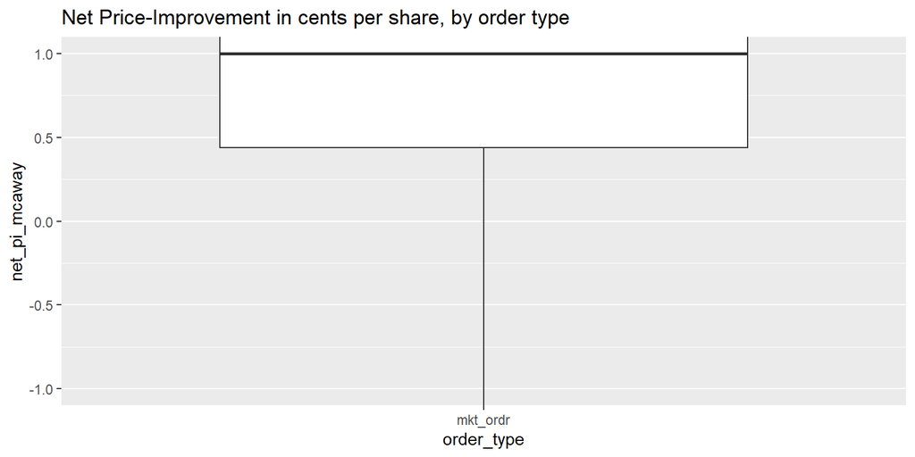

Net Price-Improvement, by order type

As many have suggested to me, I’ll concentrate on the execution quality of market-orders from here on.

### Mean or Median?

A problem with averaging a price measure like net price-improvement across stocks is that the *mean* can be overly-influenced by a stock with nominally-large share prices and spreads, e.g. Priceline or NVR, whose shares have topped $1,000 apiece. Data entry errors can also overly influence a mean. The graphic, below, of the distribution of net p-i across the stocks in your Form 605 reports allows you to see such “outliers”.

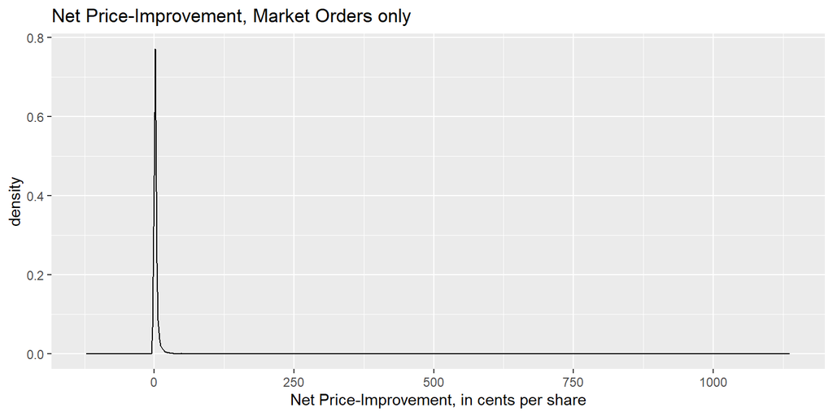

Net Price-Improvement, Market Orders only

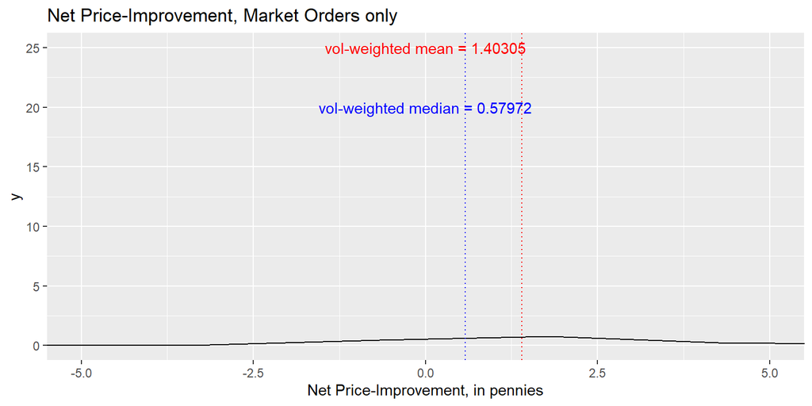

A boxplot shows outliers more clearly:

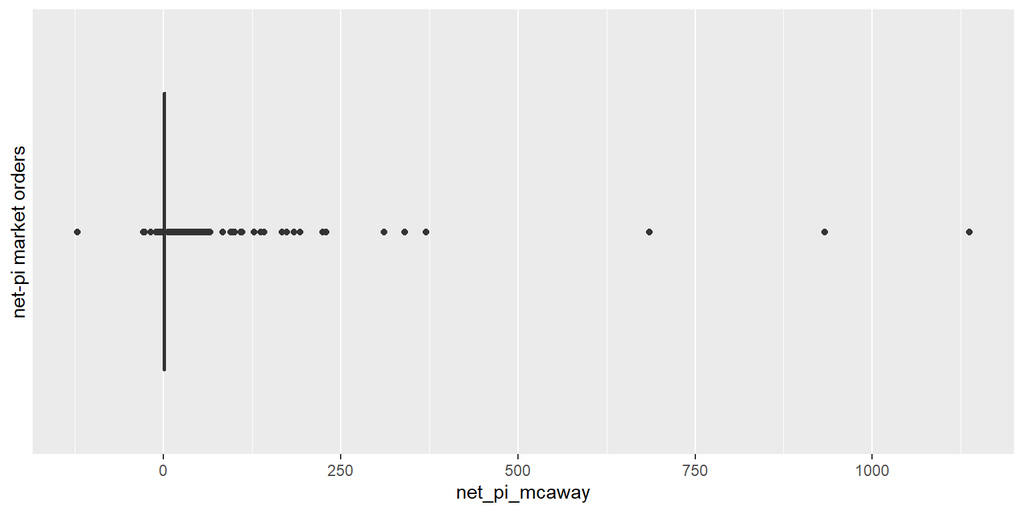

Net Price-Improvement, all stocks, all months

These are the 15 extreme values at the bottom and top of your net price improvement:

Top extreme values of net price-improvement

|  | market_center | date | ticker | order_type | order_size | net_pi_mcaway |
| --- | --- | --- | --- | --- | --- | --- |
| 1 | TCDRG | 202212 | NVR | mkt_ordr | 100-499 | 1137.0900 |
| 2 | TCDRG | 202212 | TPL | mkt_ordr | 100-499 | 932.9200 |
| 3 | TCDRG | 202212 | WTM | mkt_ordr | 100-499 | 685.2700 |
| 4 | TCDRG | 202212 | AZO | mkt_ordr | 100-499 | 370.2500 |
| 5 | TCDRG | 202212 | MTD | mkt_ordr | 100-499 | 340.2800 |
| 6 | TCDRG | 202212 | ATRI | mkt_ordr | 100-499 | 311.0600 |
| 7 | TCDRG | 202212 | BKNG | mkt_ordr | 100-499 | 229.6300 |
| 8 | TCDRG | 202212 | AGM A | mkt_ordr | 100-499 | 225.0000 |
| 9 | TCDRG | 202212 | CABO | mkt_ordr | 100-499 | 192.9300 |
| 10 | TCDRG | 202212 | USB A | mkt_ordr | 100-499 | 184.3003 |
| 11 | TCDRG | 202212 | DJCO | mkt_ordr | 100-499 | 174.1800 |
| 12 | TCDRG | 202212 | CMG | mkt_ordr | 100-499 | 167.4600 |
| 13 | TCDRG | 202212 | NWLI | mkt_ordr | 100-499 | 141.3900 |
| 14 | TCDRG | 202212 | FCNCA | mkt_ordr | 100-499 | 137.2799 |
| 15 | TCDRG | 202212 | WFC L | mkt_ordr | 100-499 | 128.0544 |

Bottom extreme values of net price-improvement

|  | market_center | date | ticker | order_type | order_size | net_pi_mcaway |
| --- | --- | --- | --- | --- | --- | --- |
| 1 | TCDRG | 202212 | FBGX | mkt_ordr | 100-499 | -121.3373 |
| 2 | TCDRG | 202212 | SFBC | mkt_ordr | 100-499 | -28.1250 |
| 3 | TCDRG | 202212 | BAC L | mkt_ordr | 100-499 | -26.3464 |
| 4 | TCDRG | 202212 | GECCO | mkt_ordr | 100-499 | -18.6000 |
| 5 | TCDRG | 202212 | CHRG | mkt_ordr | 100-499 | -10.2124 |
| 6 | TCDRG | 202212 | XCOR | mkt_ordr | 100-499 | -8.0073 |
| 7 | TCDRG | 202212 | AHT F | mkt_ordr | 100-499 | -3.5733 |
| 8 | TCDRG | 202212 | ROSE | mkt_ordr | 100-499 | -3.4229 |
| 9 | TCDRG | 202212 | DBEH | mkt_ordr | 100-499 | -3.3761 |
| 10 | TCDRG | 202212 | SAL | mkt_ordr | 100-499 | -2.0147 |
| 11 | TCDRG | 202212 | ARMR | mkt_ordr | 100-499 | -1.8967 |
| 12 | TCDRG | 202212 | SIXS | mkt_ordr | 100-499 | -1.4638 |
| 13 | TCDRG | 202212 | GBLD | mkt_ordr | 100-499 | -1.4295 |
| 14 | TCDRG | 202212 | VAL WS | mkt_ordr | 100-499 | -1.3608 |
| 15 | TCDRG | 202212 | SUNL WS | mkt_ordr | 100-499 | -0.9225 |

**Please glance at these values to alert me to any that seem to be data-entry errors in the raw Form 605.**

The influence of extreme outliers on a mean, is one reason I’m inclined to think that the mean is less representative than the median of the price-improvement that a customer’s likely to get. One can argue that some kind of trimmed-mean could exclude a certain outliers, but trimming criteria raise concerns about their arbitrariness or cherry-picking.

Volume-weighting makes both the mean and the median more representative, but the median still seems a better estimate of where a random order’s execution would lie.

Indeed, the volume-weighted median is sort of a *probability*-weighted measure, giving the most weight to where the volume is and is therefore a good representation of the execution levels typically seen by the market center and its customers (given the limits of the Form 605 raw data).

### Comparing Categories

We can see whether the median net price-improvement is much affected by a stock’s exchange listing or its size (for which, we use the proxy of its membership in the S&P 500 or the Russell 1000).

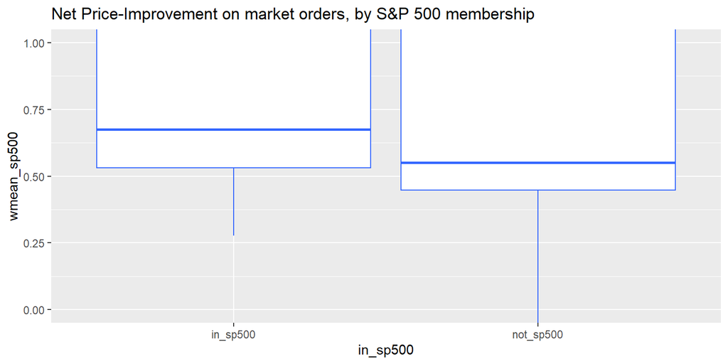

Net Price-Improvement on market orders, by S&P 500 membership

Here’s the net cents p-i for Russell 1000 membership and, *more importantly*, for Russell non-membership – to look at execution for *illiquid* names:

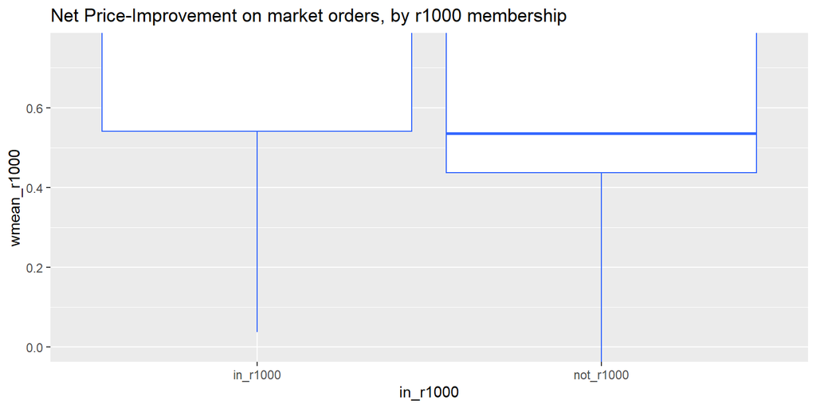

Net Price-Improvement on market orders, by r1000 membership

Here’s the net p-i for NYSE listing:

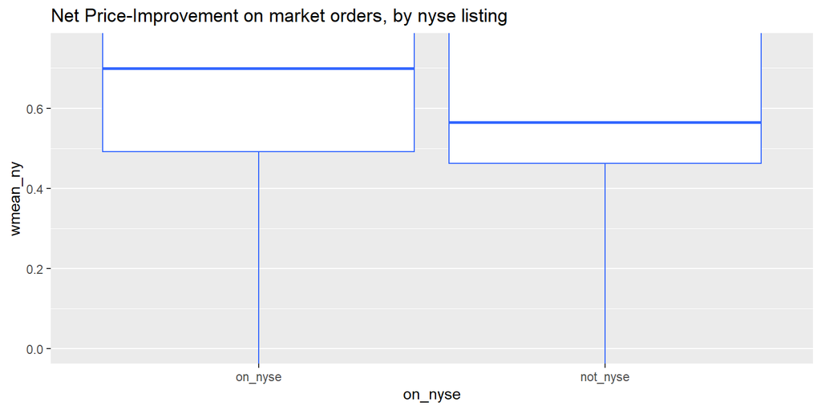

Net Price-Improvement on market orders, by NYSE listing

And for Nasdaq listing:

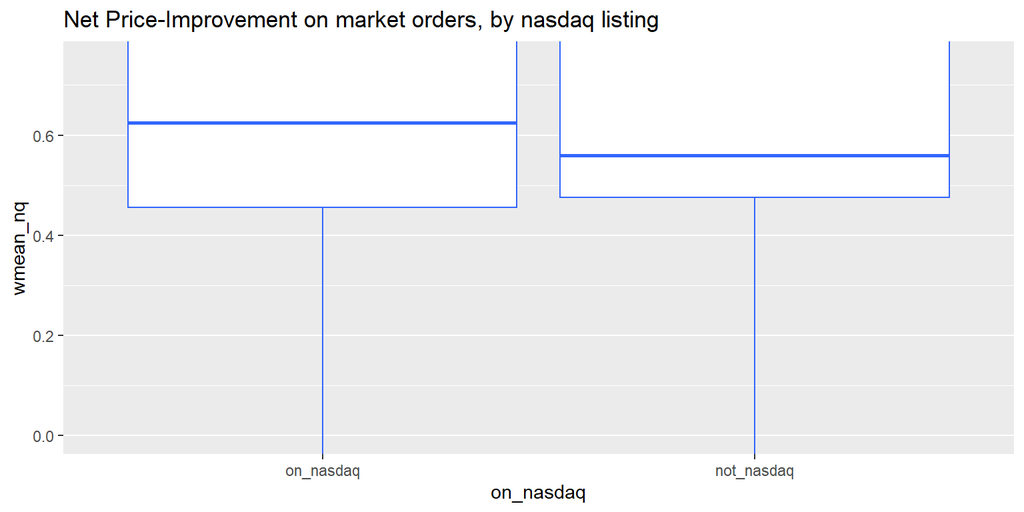

Net Price-Improvement on market orders, by Nasdaq listing

Because market centers have different mixes of order flow, a kind of standard can be imposed on their comparison if we compare them all on their execution of S&P 500-member stocks. That’s what I’ll do.

### Order Size

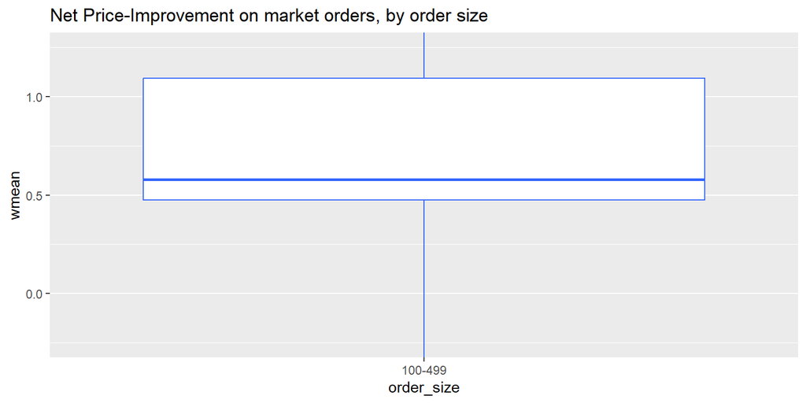

Net Price-Improvement, by order size

## More than One Market Center?

If your Form 605 reports on more than one market center, here’s how their net price-improvement on S&P 500-indexed stocks compares, for market orders. Otherwise ignore this section:

Does the Form 605 show multiple market centers?

|  | market_center | mc_wmean | mc_wmed |
| --- | --- | --- | --- |
| 1 | TCDRG | 1.77 | 0.67 |

## Aggregating by Ticker

Many firms apparently analyse their execution quality by ticker, aggregating the Form 605’s rows of order_type and order_size for each stock. That throws away some detail in the raw form, but I looked at the resulting execution measures. Before aggregating, I filtered out all order types except market-orders.

Here’s a few rows from my ticker-level table **‘f605_morder_ticker_df’**

Some Rows and Columns from the f605_morder_ticker_df data frame

|  | ticker | order_type.x | mcaway_exec_shrs_t | avg_effec_spread_t | px_improved_shrs_t | px_improved_avg_amt_t | outside_quote_shrs_t | outside_quote_avg_amt_t | effective_over_quoted_mcaway_t | order_type.y | in_sp500 | on_nyse | on_nasdaq | net_pi_mcaway_t |
| --- | --- | --- | --- | --- | --- | --- | --- | --- | --- | --- | --- | --- | --- | --- |
| 1 | A | mkt_ordr | 63813.0000 | 0.0237 | 62920.0000 | 0.0519 | 391 | 0.0282 | 0.1885 | mkt_ordr | TRUE | TRUE | FALSE | 5.1001 |
| 2 | AA | mkt_ordr | 502256.0000 | 0.0043 | 495284.0000 | 0.0132 | 1025 | 0.0163 | 0.1421 | mkt_ordr | TRUE | TRUE | FALSE | 1.2984 |
| 3 | AAA | mkt_ordr | 100.0000 | 0.0400 | 100.0000 | 0.0100 | 0 |  | 0.6667 | mkt_ordr | FALSE | FALSE | FALSE |  |
| 4 | AAAU | mkt_ordr | 50675.0000 | 0.0015 | 46493.0000 | 0.0046 | 0 |  | 0.1509 | mkt_ordr | FALSE | FALSE | FALSE |  |
| 5 | AAC | mkt_ordr | 3920.0000 | 0.0032 | 3920.0000 | 0.0035 | 0 |  | 0.3137 | mkt_ordr | FALSE | TRUE | FALSE |  |
| 6 | AAC U | mkt_ordr | 416.0000 | 0.0598 | 200.0000 | 0.0308 | 0 |  | 0.6688 | mkt_ordr | FALSE | FALSE | FALSE |  |
| 7 | AAC WS | mkt_ordr | 970.0000 | 0.0350 | 150.0000 | 0.0010 | 0 |  | 0.9912 | mkt_ordr | FALSE | FALSE | FALSE |  |
| 8 | AACG | mkt_ordr | 1640.0000 | 0.0732 | 1640.0000 | 0.0107 | 0 |  | 0.7738 | mkt_ordr | FALSE | FALSE | FALSE |  |
| 9 | AACI | mkt_ordr | 398.0000 | 0.0500 | 398.0000 | 0.0100 | 0 |  | 0.7143 | mkt_ordr | FALSE | FALSE | FALSE |  |
| 10 | AACIW | mkt_ordr | 600.0000 | 0.0167 | 110.0000 | 0.0176 | 0 |  | 0.7213 | mkt_ordr | FALSE | FALSE | FALSE |  |

Among tickers, here is the overall average net price-improvement (in cents per share), calculated various ways.

Net price-improvement averages of tickers

|  | net_pi |
| --- | --- |
| share-wgtd mean | 1.4089 |
| S&P 500 stks share_wgtd mean | 1.7645 |
| share-wgtd median | 0.6103 |
| S&P 500 stks share-wgtd median | 0.7940 |

Compare these ticker-aggregate averages to the underlying row-level averages that we analyzed above.

Net price-improvement averages of rows

[output not shown]

## Effective-over-Quoted Spreads

I calculated effective-over-quoted spreads by first creating for each row a variable **avg_quoted_spread_mcaway**, i.e. ask price minus bid price, using the share-weighted net-price-improvement measures I’d previously-created, where the denominator is orders executed at *and* away from the market-center (see discussion above, for my rationale).

Again, I only consider market_orders and I premultiply “average effective spread per share” by 100, as I previously did “net price improvement per share,” to have everything in cents.

The formulae for these variables are:

> avg_quoted_spread_mcaway = (100* avg_effec_spread + 2* net_pi_mcaway)

and

> effective_over_quoted_mcaway = (100* avg_effec_spread / avg_quoted_spread_mcaway)

> eoq_wgt <- (mcaway_exec_shrs * avg_quoted_spread_mcaway)

Effective-over-Quoted Spreads on market-orders

|  | eoq |
| --- | --- |
| Effective-over_Quoted weighted-mean | 0.2480 |
| S&P 500 Effective-over_Quoted weighted-mean | 0.1305 |
| Non-S&P 500 Effective-over_Quoted weighted-mean | 0.2837 |
| Effective-over_Quoted weighted-median | 0.1892 |
| S&P 500 Effective-over_Quoted weighted-median | 0.1158 |
| Non-S&P 500 Effective-over_Quoted weighted-median | 0.2411 |

# Order size and Effective-over-Quoted Spreads

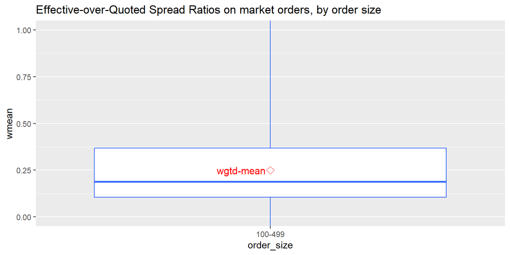

Effective-over-Quoted (market orders), by order size

## Reproducing this analysis

You can reproduce this analysis by using RStudio to open the file **“form605_makefile.R”**, which you’ll find in the directory **“./data/gather_source”**. Click on the “Source” button you’ll see to the upper right of the file window and the script will automatically run through the data-cleaning and analysis that I performed. It will also save MS Excel-readable files with the calculated numbers, in the directory **“.analysis/results_data”**, including a large spreadsheet file that has the Form 605 data that’s been cleaned up and formatted.

We’ve undertaken the effort to give you these “replication files” so that you can see exactly what we’ve done, so please take a look at our work and critique it.

Thanks!

Bill Alpert 212.416.2742 (w) william.alpert@barrons.com

[^1]: https://rmarkdown.rstudio.com
[^2]: https://www.r-project.org
[^3]: https://www.rstudio.com